# Relatório zero inflacionados

Maria Luísa de Medeiros Falcão

2025-10-22

## 1 Introdução

Distribuições para dados zero-inflacionados Em dados de contagem, é comum observar um número excessivo de zeros em relação ao esperado por distribuições como a Poisson ou a Binomial Negativa. Nesses casos temos um zero-inflation e pode ocorrer, por exemplo, quando há amostras onde a espécie realmente não pode ocorrer (zeros estruturais), além de zeros por erro de amostragem. Para lidar com essa característica, utilizam-se modelos de distribuição zero-inflacionada, como os modelos Zero-Inflated Poisson (ZIP) e Zero-Inflated Negative Binomial (ZINB), ou os ZAP = Zero-altered Poisson; ZANB = Zero-altered Negative Binomial. Esses modelos combinam dois processos: um que modela a ocorrência de zeros e outro que modela a contagem quando o evento é possível.

## 2 Conjunto de dados

Para exemplificarmos essas duas distribuições usaremos um conjunto de dados de salamdras, armazenados no diretório `/Dados` da disciplina. Os dados reúne informações sobre a contagem de diversas espécies de salamandras, com amostragens realizadas ao longo de 23 rios.

Definindo diretório e importando o banco de dados

```r
setwd("~/Doutorado/Disciplinas/GLM/ECL0072-GLM_GAM-gh-pages/ECL0072-GLM_GAM-gh-pages")

#Importando dados
dados <- readRDS("Dados/Salamanders.rds")
```

Ver os dados

```r
View(dados)
str(dados)
```

```
## 'data.frame':    92 obs. of  14 variables:
##  $ site                      : Ord.factor w/ 23 levels "R-1"<"R-2"<"R-3"<..: 1 1 1 1 2 2 2 2 3 3 ...
##  $ mined                     : Factor w/ 2 levels "yes","no": 2 2 2 2 2 2 2 2 2 2 ...
##  $ cover                     : num  -0.448 -0.448 -0.448 -0.448 0.597 ...
##  $ sample                    : int  1 2 3 4 1 2 3 4 1 2 ...
##  $ DOP                       : num  0 -0.3018 0 -0.0916 0.5957 ...
##  $ Wtemp                     : num  -3.023 -1.365 -0.583 0.18 -0.144 ...
##  $ DOY                       : num  -2.712 -0.525 0.164 1.257 -0.687 ...
##  $ Gyrinophilus_porphyriticus: int  2 1 6 2 2 5 5 0 1 6 ...
##  $ Pseudotriton_ruber        : int  4 0 2 1 0 0 0 0 0 0 ...
##  $ Desmognathus_monticola    : int  3 2 3 2 4 6 3 3 1 4 ...
##  $ Eurycea_cirrigera_Adult   : int  2 0 0 0 0 0 2 0 2 0 ...
##  $ Eurycea_cirrigera_Larval  : int  1 6 4 13 2 2 3 11 0 0 ...
##  $ Desmognathus_spp_Larval   : int  1 8 7 2 4 2 14 0 10 8 ...
##  $ Desmognathus_fuscus       : int  1 0 0 0 1 1 1 2 0 0 ...
```

Pelo jeito “mined” já está como fator, então não precisa de transformação.

Vamos ver a frequência de zeros na variável resposta (abundância) Para isso, primeiramente criaremos um objeto “especies” para se referir as espécies

```r
especies <- c("Gyrinophilus_porphyriticus",
              "Pseudotriton_ruber",
              "Desmognathus_monticola",
              "Eurycea_cirrigera_Adult",
              "Eurycea_cirrigera_Larval",
              "Desmognathus_spp_Larval",
              "Desmognathus_fuscus")
```

Vamos criar uma tabela com proporção de zeros: Para isso usando o “sapply()” se aplica uma função a cada coluna (as espécies) do data frame. O “funtion(x) eu determino que para cada coluna, você vai executar a operação mean(x == 0). Este (x == 0) cria um vetor de TRUE (1) - que é a presença de zero e FALSE (0) - que é a ausência de 0, e o mean faz a média desses valores (0 e 1) dando a proporção de 0 para cada espécie

```r
proporcao_zeros <- sapply(dados[, especies], function(x) mean(x == 0))
proporcao_zeros
```

```
## Gyrinophilus_porphyriticus         Pseudotriton_ruber
##                  0.5869565                  0.8478261
##     Desmognathus_monticola    Eurycea_cirrigera_Adult
##                  0.5108696                  0.7717391
##   Eurycea_cirrigera_Larval    Desmognathus_spp_Larval
##                  0.5108696                  0.4673913
##        Desmognathus_fuscus
##                  0.5108696
```

Vamos ver como estão distribuídas as abundâncias em torno de areas mineradas ou não. Para rodar de uma vez para cada espécie eu vou fazer um “loop”

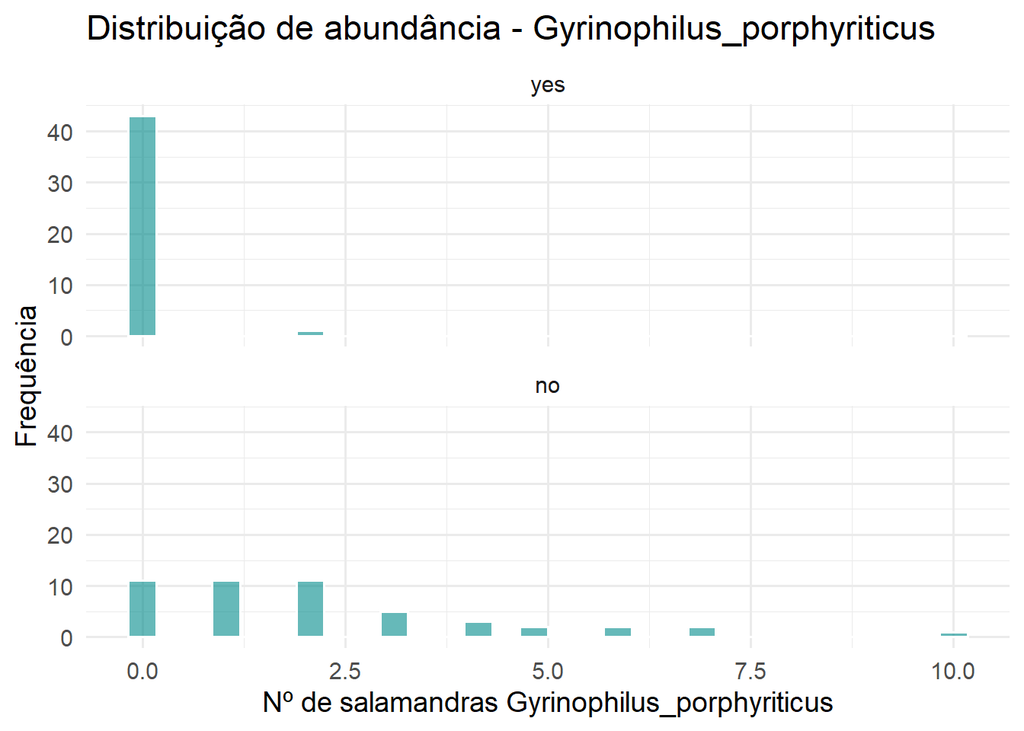

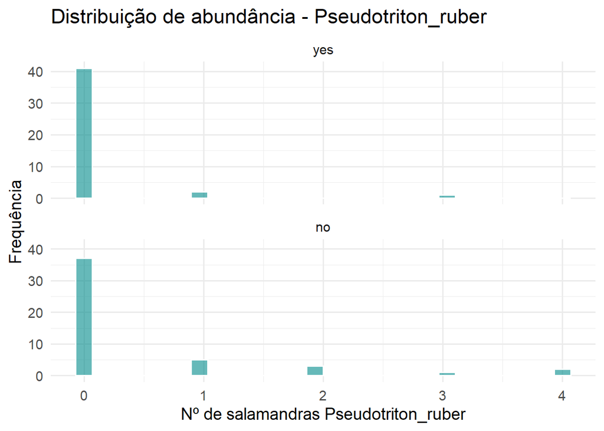

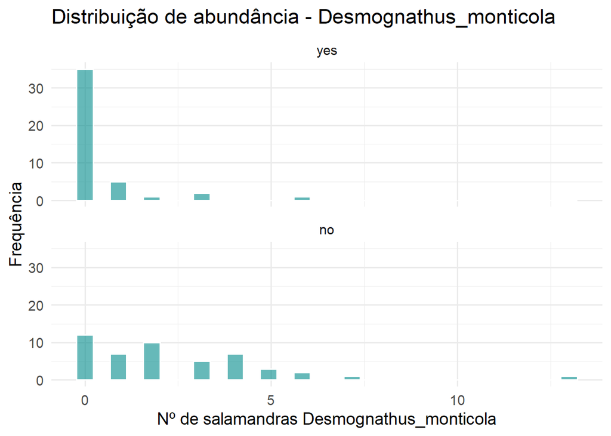

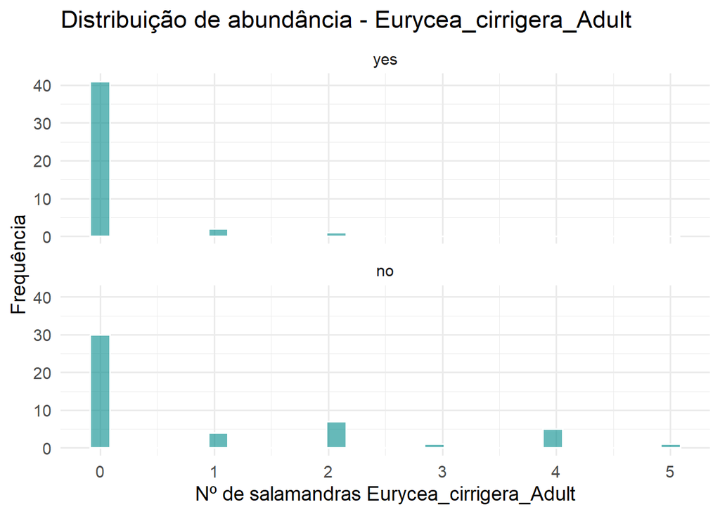

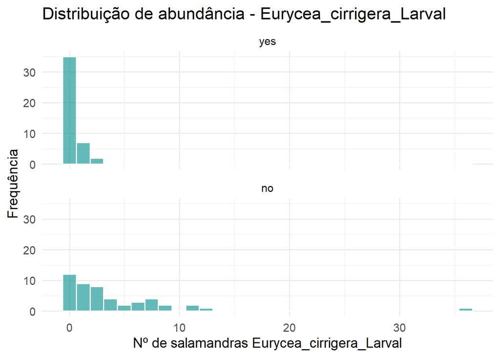

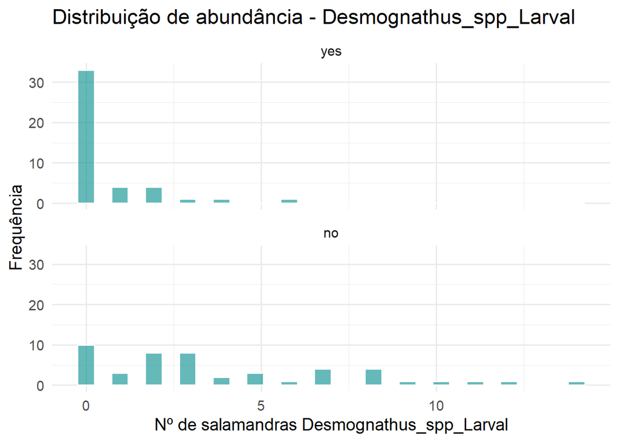

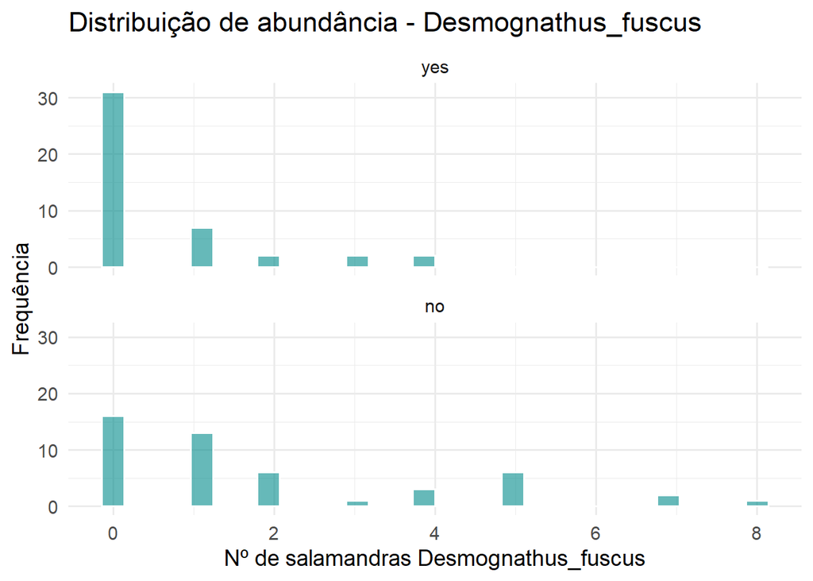

```r
for(sp in especies){ #roda o código uma vez para cada espécie da lista
  p <- ggplot(dados, aes_string(x = sp)) +
    geom_histogram(fill = "cyan4", alpha = 0.6, col = "white") +
    facet_wrap(~ mined, ncol = 1) +
    labs(x = paste("Nº de salamandras", sp),
         y = "Frequência") +
    ggtitle(paste("Distribuição de abundância -", sp)) +
    theme_minimal(base_size = 14)

  print(p) # mostra o gráfico
}
```

Y = Frequencia, aqui é número de amostras que tiveram essa quantidade e x = quantidade de salamandras contadas na amostra. Observamos que em locais com mineradoras apresentam mais zeros em numero de salamandras encontradas comparado a locais sem mineradora

Agora vamos rodar os modelos de ZIP e ZINB, para isso: Fazemos uma lista vazia onde vamos guardar os modelos de cada espécie.

```r
resultados <- list()

for(sp in especies){
  formula <- as.formula(paste(sp, "~ mined"))
  modelos <- glmmTMB(formula,
                     ziformula = ~1, #Estamos considerando apenas o intercepto (sem covariáveis) na parte zero-inflada do modelo. Ou seja, a probabilidade de gerar um zero estrutural é a mesma para todas as observações.
                     family = poisson,
                     data = dados)
  resultados[[sp]] <- modelos
}
```

Mesma coisa sendo que agora pra binomial negativa

```r
resultados_nb <- list()  # nova lista para modelos binomial negativo

for(sp in especies){
  formula <- as.formula(paste(sp, "~ mined"))
  modelos <- glmmTMB(formula,
                     ziformula = ~1,
                     family = nbinom2,
                     data = dados)
  resultados_nb[[sp]] <- modelos
}
```

Calculando o AIC

```r
AIC_table <- data.frame( #aqui estamos criando uma tabela que por enquanto está vazia
  especie = especies, # nessa tabela terá a coluna especie referente pras espécies
  AIC_poisson = NA, # cria uma coluna onde terá o AIC de poisson, mas que por enquanto está vazia, por isso "NA"
  AIC_nbinom = NA # Mesma coisa sendo que pra poisson
)
```

Agora criamos o Loop para preencher os valores de AIC para cada espécie

```r
for(sp in especies){
  AIC_table[AIC_table$especie == sp, "AIC_poisson"] <- AIC(resultados[[sp]])
  AIC_table[AIC_table$especie == sp, "AIC_nbinom"]  <- AIC(resultados_nb[[sp]])
}
# Determinar o melhor modelo para cada espécie
AIC_table$melhor_modelo <- ifelse(
  AIC_table$AIC_poisson < AIC_table$AIC_nbinom,
  "Poisson",
  "Binomial Negativa"
)
```

Mostrar tabela final

```r
AIC_table
```

```
##                      especie AIC_poisson AIC_nbinom     melhor_modelo
## 1 Gyrinophilus_porphyriticus    221.1211   213.4091 Binomial Negativa
## 2         Pseudotriton_ruber    118.2364   119.8976           Poisson
## 3     Desmognathus_monticola    294.6911   283.8522 Binomial Negativa
## 4    Eurycea_cirrigera_Adult    153.6155   155.6155           Poisson
## 5   Eurycea_cirrigera_Larval    394.1862   300.7931 Binomial Negativa
## 6    Desmognathus_spp_Larval    357.1750   334.7942 Binomial Negativa
## 7        Desmognathus_fuscus    289.7957   278.0682 Binomial Negativa
```

Em sua maioria o modelo binomial negativo explicou melhor os dados. Porém o que teve menor AIC foi o modelo Poisson para espécie Pseudotriton_ruber

```r
melhor_modelo <- resultados[["Pseudotriton_ruber"]]

# Simular resíduos
simres <- simulateResiduals(melhor_modelo, n = 1000)
```

Vamos plotar os resíduos

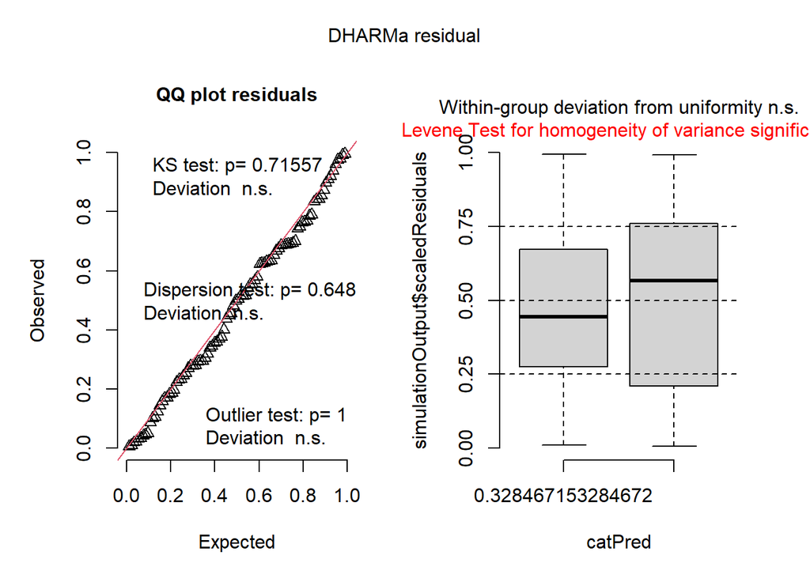

```r
plot(simres)
```

Vamos agora usar o check_model para avaliar graficamente os principais pressupostos de um modelo, mostrando se há problemas de ajuste, sobredispersão, resíduos mal distribuídos, ou heterogeneidade de variância.

```r
check_model(simres)
```

```
## `check_outliers()` does not yet support models of class `glmmTMB`.
```

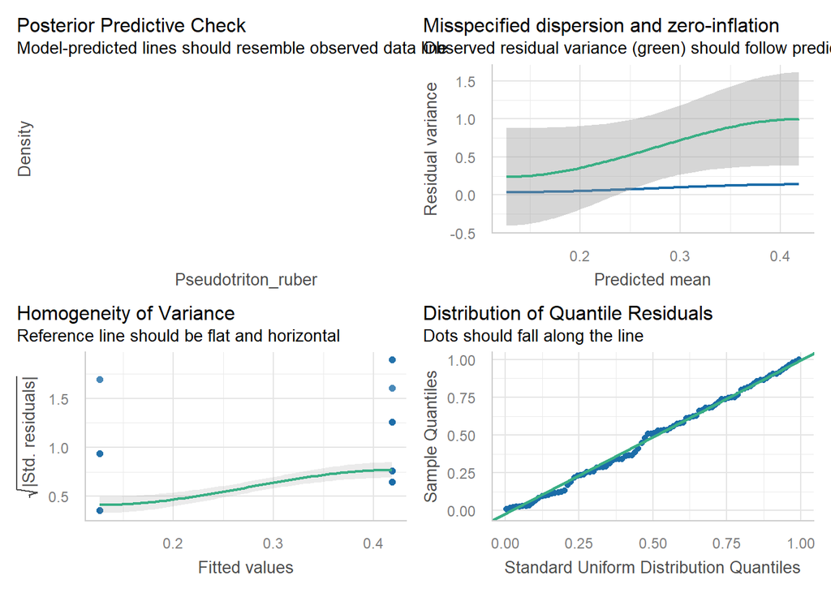

O primeiro gráfico do lado esquerdo não está aparecendo. O segundo gráfico a direita vemos que a variância dos resíduos observados está acima dos preditos, então o modelo parece estar subestimando, aperenta ter um sobredispersão. Para o gráfico de homogeneidade de variância, se espera que se forme um linha verde horizontal, no caso da imagem, ela tem um leve aumento a medida que aumenta os valores preditos, ou seja, ele indica que a variância dos resíduos aumenta com os valores previstos, que pode ser um sinal de que o modelo pode estar realmente subestimando a variabilidade para valores maiores. Para o g´rafico de distribuição de quantis de resíduos se espera que os resíduos estejam distribuídos próximo a linha verde, e eles parecem seguir esse padrão, então segundo esse gráfico, parece que os resíduos estão bem distribuídos.

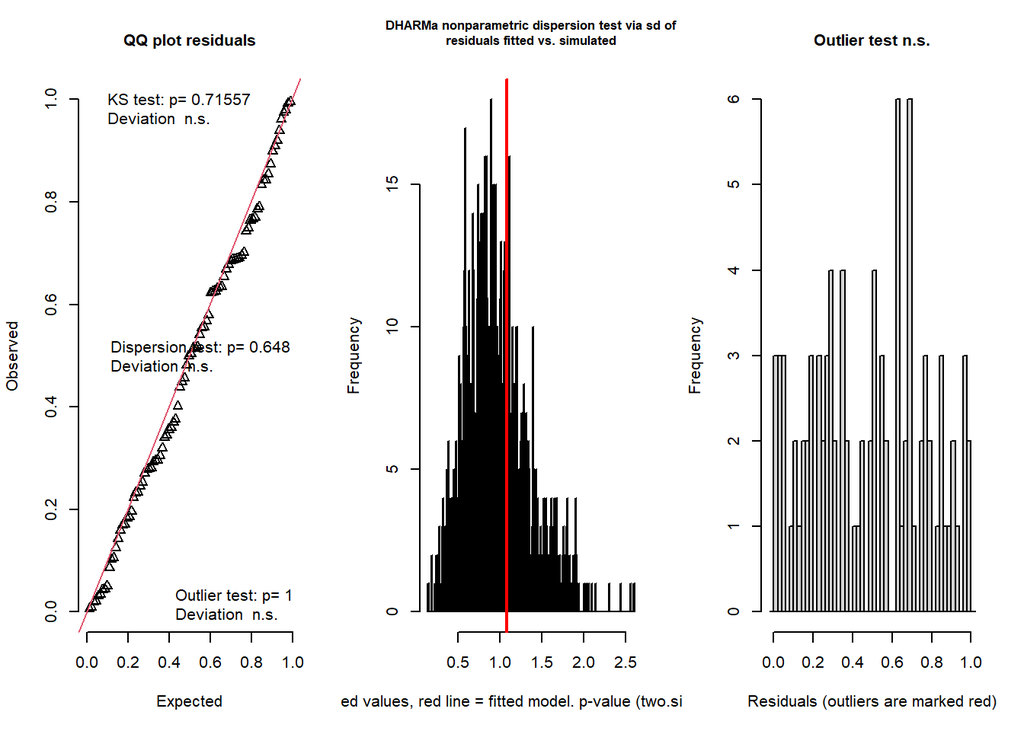

```
## $uniformity
##
##  Exact one-sample Kolmogorov-Smirnov test
##
## data:  simulationOutput$scaledResiduals
## D = 0.070991, p-value = 0.7156
## alternative hypothesis: two-sided
##
##
## $dispersion
##
##  DHARMa nonparametric dispersion test via sd of residuals fitted vs.
##  simulated
##
## data:  simulationOutput
## dispersion = 1.128, p-value = 0.648
## alternative hypothesis: two.sided
##
##
## $outliers
##
##  DHARMa bootstrapped outlier test
##
## data:  simulationOutput
## outliers at both margin(s) = 0, observations = 92, p-value = 1
## alternative hypothesis: two.sided
##  percent confidence interval:
##  0.00000000 0.01086957
## sample estimates:
## outlier frequency (expected: 0.000978260869565217 )
##                                                   0
```

```r
testResiduals(simres)
```

## 3 Agora pra ZANB e ZAP

```r
resultados_ZAP <- list()
for(sp in especies){
  formula <- as.formula(paste(sp, "~ mined"))
  modelos <- glmmTMB(formula,
                     ziformula = ~1, #Estamos considerando apenas o intercepto (sem covariáveis) na parte zero-inflada do modelo. Ou seja, a probabilidade de gerar um zero estrutural é a mesma para todas as observações.
                     family = truncated_poisson(link = "log"),
                     data = dados)
  resultados_ZAP[[sp]] <- modelos
}


resultados_ZANB <- list()
for(sp in especies){
  formula <- as.formula(paste(sp, "~ mined"))
  modelos <- glmmTMB(formula,
                     ziformula = ~1, #Estamos considerando apenas o intercepto (sem covariáveis) na parte zero-inflada do modelo. Ou seja, a probabilidade de gerar um zero estrutural é a mesma para todas as observações.
                     family = truncated_nbinom2(link = "log"),
  data = dados)
resultados_ZANB[[sp]] <- modelos
}
```

Calculando o AIC

```r
AIC_table <- data.frame( #aqui estamos criando uma tabela que por enquanto está vazia
  especie = especies, # nessa tabela terá a coluna especie referente pras espécies
  AIC_poisson = NA, # cria uma coluna onde terá o AIC de poisson, mas que por enquanto está vazia, por isso "NA"
  AIC_nbinom = NA, # Mesma coisa sendo que pra poisson
  AIC_ZANB = NA,
  AIC_ZAP = NA
)
```

Aqui criamos o Loop para preencher os valores de AIC para cada espécie

```r
for(sp in especies){
  AIC_table[AIC_table$especie == sp, "AIC_poisson"] <- AIC(resultados[[sp]])
  AIC_table[AIC_table$especie == sp, "AIC_nbinom"]  <- AIC(resultados_nb[[sp]])
  AIC_table[AIC_table$especie == sp, "AIC_ZANB"]  <- AIC(resultados_ZANB[[sp]])
  AIC_table[AIC_table$especie == sp, "AIC_ZAP"]  <- AIC(resultados_ZAP[[sp]])
}
# Determinar o melhor modelo para cada espécie
AIC_table$melhor_modelo <- ifelse(
  AIC_table$AIC_poisson < AIC_table$AIC_nbinom,
  "Poisson",
  "Binomial Negativa"
)

# Mostrar tabela final
AIC_table
```

```
##                      especie AIC_poisson AIC_nbinom AIC_ZANB  AIC_ZAP
## 1 Gyrinophilus_porphyriticus    221.1211   213.4091 272.1818 279.0775
## 2         Pseudotriton_ruber    118.2364   119.8976 123.2165 121.2823
## 3     Desmognathus_monticola    294.6911   283.8522 304.2022 310.6085
## 4    Eurycea_cirrigera_Adult    153.6155   155.6155       NA 166.1483
## 5   Eurycea_cirrigera_Larval    394.1862   300.7931 329.3226 422.9970
## 6    Desmognathus_spp_Larval    357.1750   334.7942 354.3783 370.7678
## 7        Desmognathus_fuscus    289.7957   278.0682 288.9936 297.6222
##       melhor_modelo
## 1 Binomial Negativa
## 2           Poisson
## 3 Binomial Negativa
## 4           Poisson
## 5 Binomial Negativa
## 6 Binomial Negativa
## 7 Binomial Negativa
```

Aparentemente não melhorou os modelos com ZAP e ZANB pelo AIC.